# Supervised Learning - Foundations Project: ReCell

##### A large battery often increases a device's weight, making it feel uncomfortable in the hands. How does the weight vary for phones and tablets offering large batteries (more than 4500 mAh)?

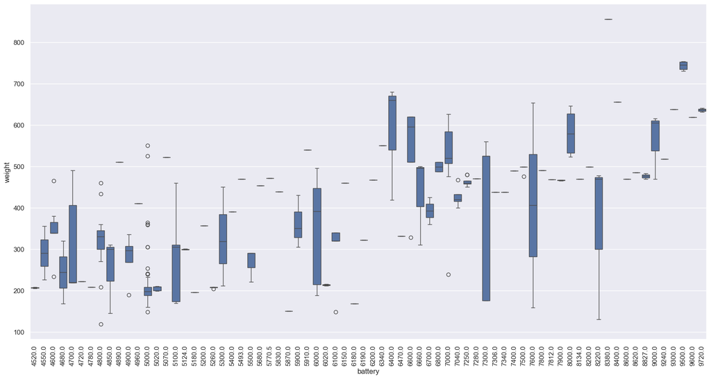

```python
large_battery2 = df3[df3.battery > 4500]

plt.figure(figsize = (20, 10))
sns.boxplot(data = large_battery2, x = 'battery', y = 'weight')
plt.xticks(rotation = 90)
plt.show();
```

##### A lot of devices nowadays offer great selfie cameras, allowing us to capture our favorite moments with loved ones. What is the distribution of devices offering greater than 8MP selfie cameras across brands?

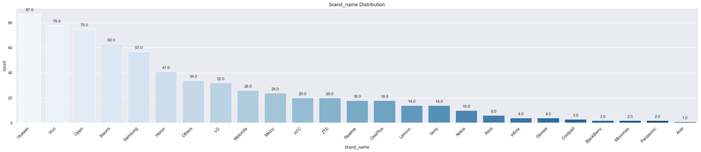

```python
selfie_camera2 = df3[df3.selfie_camera_mp > 8]
barplot(selfie_camera2, 'brand_name')
```

#### Data Preparation

```python
# Splitting the columns into dependent and independent variables

X = df3.drop('normalized_used_price', axis = 1) # Independent variables
y = df3['normalized_used_price'] # Dependent variable

print(X.head())

print(y.head())
```

```
  brand_name       os  screen_size   4g   5g  main_camera_mp  \
0      Honor  Android        14.50  yes   no            13.0
1      Honor  Android        17.30  yes  yes            13.0
2      Honor  Android        16.69  yes  yes            13.0
3      Honor  Android        25.50  yes  yes            13.0
4      Honor  Android        15.32  yes   no            13.0

   selfie_camera_mp  int_memory  ram  battery  weight  days_used  \
0               5.0        64.0  3.0   3020.0   146.0        127
1              16.0       128.0  8.0   4300.0   213.0        325
2               8.0       128.0  8.0   4200.0   213.0        162
3               8.0        64.0  6.0   7250.0   480.0        345
4               8.0        64.0  3.0   5000.0   185.0        293

   normalized_new_price  years_since_release
0              4.715100                    1
1              5.519018                    1
2              5.884631                    1
3              5.630961                    1
4              4.947837                    1
0    4.307572
1    5.162097
2    5.111084
3    5.135387
4    4.389995
Name: normalized_used_price, dtype: float64
```

```python
# Adding a constant term to the dataset
X = sm.add_constant(X)
```

```python
# Creating the dummy variables and converting them to integer form from Boolean form
X = pd.get_dummies(
    X,
    columns = X.select_dtypes(include = ["object", "category"]).columns.tolist(),
    drop_first = True
)

bool_cols = X.select_dtypes(include=["bool"]).columns
X[bool_cols] = X[bool_cols].astype(int)

X.head()
```

|  | const | screen_size | main_camera_mp | selfie_camera_mp | int_memory | ram | battery | weight | days_used | normalized_new_price | ... | brand_name_Spice | brand_name_Vivo | brand_name_XOLO | brand_name_Xiaomi | brand_name_ZTE | os_Others | os_Windows | os_iOS | 4g_yes | 5g_yes |
| --- | --- | --- | --- | --- | --- | --- | --- | --- | --- | --- | --- | --- | --- | --- | --- | --- | --- | --- | --- | --- | --- |
| 0 | 1.0 | 14.50 | 13.0 | 5.0 | 64.0 | 3.0 | 3020.0 | 146.0 | 127 | 4.715100 | ... | 0 | 0 | 0 | 0 | 0 | 0 | 0 | 0 | 1 | 0 |
| 1 | 1.0 | 17.30 | 13.0 | 16.0 | 128.0 | 8.0 | 4300.0 | 213.0 | 325 | 5.519018 | ... | 0 | 0 | 0 | 0 | 0 | 0 | 0 | 0 | 1 | 1 |
| 2 | 1.0 | 16.69 | 13.0 | 8.0 | 128.0 | 8.0 | 4200.0 | 213.0 | 162 | 5.884631 | ... | 0 | 0 | 0 | 0 | 0 | 0 | 0 | 0 | 1 | 1 |
| 3 | 1.0 | 25.50 | 13.0 | 8.0 | 64.0 | 6.0 | 7250.0 | 480.0 | 345 | 5.630961 | ... | 0 | 0 | 0 | 0 | 0 | 0 | 0 | 0 | 1 | 1 |
| 4 | 1.0 | 15.32 | 13.0 | 8.0 | 64.0 | 3.0 | 5000.0 | 185.0 | 293 | 4.947837 | ... | 0 | 0 | 0 | 0 | 0 | 0 | 0 | 0 | 1 | 0 |

5 rows × 49 columns

```python
# Splitting the dataset into trin and test in the 70:30 ratio
X_train, X_test, y_train, y_test = train_test_split(
    X, y, test_size = 0.30, random_state = 1
)
```

## Model Building - Linear Regression

```python
model = sm.OLS(y_train, X_train).fit()
print(model.summary())
```

```
                              OLS Regression Results
=================================================================================
Dep. Variable:     normalized_used_price   R-squared:                       0.845
Model:                               OLS   Adj. R-squared:                  0.842
Method:                    Least Squares   F-statistic:                     268.7
Date:                   Sat, 12 Apr 2025   Prob (F-statistic):               0.00
Time:                           15:59:34   Log-Likelihood:                 123.85
No. Observations:                   2417   AIC:                            -149.7
Df Residuals:                       2368   BIC:                             134.0
Df Model:                             48
Covariance Type:               nonrobust
=========================================================================================
                            coef    std err          t      P>|t|      [0.025      0.975]
-----------------------------------------------------------------------------------------
const                     1.3156      0.071     18.454      0.000       1.176       1.455
screen_size               0.0244      0.003      7.163      0.000       0.018       0.031
main_camera_mp            0.0208      0.002     13.848      0.000       0.018       0.024
selfie_camera_mp          0.0135      0.001     11.997      0.000       0.011       0.016
int_memory                0.0001   6.97e-05      1.651      0.099   -2.16e-05       0.000
ram                       0.0230      0.005      4.451      0.000       0.013       0.033
battery               -1.689e-05   7.27e-06     -2.321      0.020   -3.12e-05   -2.62e-06
weight                    0.0010      0.000      7.480      0.000       0.001       0.001
days_used              4.216e-05   3.09e-05      1.366      0.172   -1.84e-05       0.000
normalized_new_price      0.4311      0.012     35.147      0.000       0.407       0.455
years_since_release      -0.0237      0.005     -5.193      0.000      -0.033      -0.015
brand_name_Alcatel        0.0154      0.048      0.323      0.747      -0.078       0.109
brand_name_Apple         -0.0038      0.147     -0.026      0.980      -0.292       0.285
brand_name_Asus           0.0151      0.048      0.314      0.753      -0.079       0.109
brand_name_BlackBerry    -0.0300      0.070     -0.427      0.669      -0.168       0.108
brand_name_Celkon        -0.0468      0.066     -0.707      0.480      -0.177       0.083
brand_name_Coolpad        0.0209      0.073      0.287      0.774      -0.122       0.164
brand_name_Gionee         0.0448      0.058      0.775      0.438      -0.068       0.158
brand_name_Google        -0.0326      0.085     -0.385      0.700      -0.199       0.133
brand_name_HTC           -0.0130      0.048     -0.270      0.787      -0.108       0.081
brand_name_Honor          0.0317      0.049      0.644      0.520      -0.065       0.128
brand_name_Huawei        -0.0020      0.044     -0.046      0.964      -0.089       0.085
brand_name_Infinix        0.1633      0.093      1.752      0.080      -0.019       0.346
brand_name_Karbonn        0.0943      0.067      1.405      0.160      -0.037       0.226
brand_name_LG            -0.0132      0.045     -0.291      0.771      -0.102       0.076
brand_name_Lava           0.0332      0.062      0.533      0.594      -0.089       0.155
```

[output cut: 19 more lines]

```
os_Windows               -0.0207      0.045     -0.459      0.646      -0.109       0.068
os_iOS                   -0.0663      0.146     -0.453      0.651      -0.354       0.221
4g_yes                    0.0528      0.016      3.326      0.001       0.022       0.084
5g_yes                   -0.0714      0.031     -2.268      0.023      -0.133      -0.010
==============================================================================
Omnibus:                      223.612   Durbin-Watson:                   1.910
Prob(Omnibus):                  0.000   Jarque-Bera (JB):              422.275
Skew:                          -0.620   Prob(JB):                     2.01e-92
Kurtosis:                       4.630   Cond. No.                     1.78e+05
==============================================================================

Notes:
[1] Standard Errors assume that the covariance matrix of the errors is correctly specified.
[2] The condition number is large, 1.78e+05. This might indicate that there are
strong multicollinearity or other numerical problems.
```

## Model Performance Check

```python
# function to compute adjusted R-squared
def adj_r2_score(predictors, targets, predictions):
    r2 = r2_score(targets, predictions)
    n = predictors.shape[0]
    k = predictors.shape[1]
    return 1 - ((1 - r2) * (n - 1) / (n - k - 1))


# function to compute MAPE
def mape_score(targets, predictions):
    return np.mean(np.abs(targets - predictions) / targets) * 100


# function to compute different metrics to check performance of a regression model
def model_performance_regression(model, predictors, target):
    """
    Function to compute different metrics to check regression model performance

    model: regressor
    predictors: independent variables
    target: dependent variable
    """

    # predicting using the independent variables
    pred = model.predict(predictors)

    r2 = r2_score(target, pred)  # to compute R-squared
    adjr2 = adj_r2_score(predictors, target, pred)  # to compute adjusted R-squared
    rmse = np.sqrt(mean_squared_error(target, pred))  # to compute RMSE
    mae = mean_absolute_error(target, pred)  # to compute MAE
    mape = mape_score(target, pred)  # to compute MAPE

    # creating a dataframe of metrics
    df_perf = pd.DataFrame(
        {
            "RMSE": rmse,
            "MAE": mae,
            "R-squared": r2,
            "Adj. R-squared": adjr2,
            "MAPE": mape,
        },
        index=[0],
    )

    return df_perf
```

```python
# checking model performance on train set (seen 70% data)
print("Training Performance\n")
model_train_performance = model_performance_regression(model, X_train, y_train)
model_train_performance
```

```
Training Performance
```

|  | RMSE | MAE | R-squared | Adj. R-squared | MAPE |
| --- | --- | --- | --- | --- | --- |
| 0 | 0.229884 | 0.180326 | 0.844886 | 0.841675 | 4.326841 |

```python
# checking model performance on test set (seen 30% data)
print("Test Performance\n")
model_test_perfomance = model_performance_regression(model, X_test, y_test) ## Complete the code to check the performance on test data
model_test_perfomance
```

```
Test Performance
```

|  | RMSE | MAE | R-squared | Adj. R-squared | MAPE |
| --- | --- | --- | --- | --- | --- |
| 0 | 0.238358 | 0.184749 | 0.842479 | 0.834659 | 4.501651 |

**Observations**

## Checking Linear Regression Assumptions

- In order to make statistical inferences from a linear regression model, it is important to ensure that the assumptions of linear regression are satisfied.
1. **No Multicollinearity**
2. **Linearity of variables**
3. **Independence of error terms**
4. **Normality of error terms**
5. **No Heteroscedasticity**

### 1. TEST FOR MULTICOLLINEARITY

```python
def checking_vif(predictors):
    vif = pd.DataFrame()
    vif["feature"] = predictors.columns

    # calculating VIF for each feature
    vif["VIF"] = [
        variance_inflation_factor(predictors.values, i)
        for i in range(len(predictors.columns))
    ]
    return vif
```

```python
checking_vif(X_train)
```

|  | feature | VIF |
| --- | --- | --- |
| 0 | const | 227.744081 |
| 1 | screen_size | 7.677290 |
| 2 | main_camera_mp | 2.285051 |
| 3 | selfie_camera_mp | 2.812473 |
| 4 | int_memory | 1.364152 |
| 5 | ram | 2.282352 |
| 6 | battery | 4.081780 |
| 7 | weight | 6.396749 |
| 8 | days_used | 2.660269 |
| 9 | normalized_new_price | 3.119430 |
| 10 | years_since_release | 4.899007 |
| 11 | brand_name_Alcatel | 3.405693 |
| 12 | brand_name_Apple | 13.057668 |
| 13 | brand_name_Asus | 3.332038 |
| 14 | brand_name_BlackBerry | 1.632378 |
| 15 | brand_name_Celkon | 1.774721 |
| 16 | brand_name_Coolpad | 1.468006 |
| 17 | brand_name_Gionee | 1.951272 |
| 18 | brand_name_Google | 1.321778 |
| 19 | brand_name_HTC | 3.410361 |
| 20 | brand_name_Honor | 3.340687 |
| 21 | brand_name_Huawei | 5.983852 |
| 22 | brand_name_Infinix | 1.283955 |
| 23 | brand_name_Karbonn | 1.573702 |
| 24 | brand_name_LG | 4.849832 |
| 25 | brand_name_Lava | 1.711360 |
| 26 | brand_name_Lenovo | 4.558941 |
| 27 | brand_name_Meizu | 2.179607 |
| 28 | brand_name_Micromax | 3.363521 |
| 29 | brand_name_Microsoft | 1.869751 |
| 30 | brand_name_Motorola | 3.274558 |
| 31 | brand_name_Nokia | 3.479849 |
| 32 | brand_name_OnePlus | 1.437034 |
| 33 | brand_name_Oppo | 3.971194 |
| 34 | brand_name_Others | 9.711034 |
| 35 | brand_name_Panasonic | 2.105703 |
| 36 | brand_name_Realme | 1.946812 |
| 37 | brand_name_Samsung | 7.539866 |
| 38 | brand_name_Sony | 2.943161 |
| 39 | brand_name_Spice | 1.688863 |
| 40 | brand_name_Vivo | 3.651437 |
| 41 | brand_name_XOLO | 2.138070 |
| 42 | brand_name_Xiaomi | 3.719689 |
| 43 | brand_name_ZTE | 3.797581 |
| 44 | os_Others | 1.859863 |
| 45 | os_Windows | 1.596034 |
| 46 | os_iOS | 11.784684 |
| 47 | 4g_yes | 2.467681 |
| 48 | 5g_yes | 1.813900 |

- There are multiple columns with very high VIF values, indicating presence of strong multicollinearity.
- We will systematically drop numerical columns with VIF > 5 except the VIF values for dummy variables and the constant (intercept).

```python
# Removing multicollinearity

def treating_multicollinearity(predictors, target, high_vif_columns):
    """
    Checking the effect of dropping the columns showing high multicollinearity
    on model performance (adj. R-squared and RMSE)

    predictors: independent variables
    target: dependent variable
    high_vif_columns: columns having high VIF
    """
    # empty lists to store adj. R-squared and RMSE values
    adj_r2 = []
    rmse = []

    # build ols models by dropping one of the high VIF columns at a time
    # store the adjusted R-squared and RMSE in the lists defined previously
    for cols in high_vif_columns:
        # defining the new train set
        train = predictors.loc[:, ~predictors.columns.str.startswith(cols)]

        # create the model
        olsmodel = sm.OLS(target, train).fit()

        # adding adj. R-squared and RMSE to the lists
        adj_r2.append(olsmodel.rsquared_adj)
        rmse.append(np.sqrt(olsmodel.mse_resid))

    # creating a dataframe for the results
    temp = pd.DataFrame(
        {
            "col": high_vif_columns,
            "Adj. R-squared after_dropping col": adj_r2,
            "RMSE after dropping col": rmse,
        }
    ).sort_values(by="Adj. R-squared after_dropping col", ascending=False)
    temp.reset_index(drop=True, inplace=True)

    return temp
```

```python
col_list = ["screen_size", "weight"]

res = treating_multicollinearity(X_train, y_train, col_list)
res
```

|  | col | Adj. R-squared after_dropping col | RMSE after dropping col |
| --- | --- | --- | --- |
| 0 | screen_size | 0.838381 | 0.234703 |
| 1 | weight | 0.838071 | 0.234928 |

```python
col_to_drop = "screen_size"
X_train2 = X_train.loc[:, ~X_train.columns.str.startswith(col_to_drop)]
X_test2 = X_test.loc[:, ~X_test.columns.str.startswith(col_to_drop)]

# Check VIF now
vif = checking_vif(X_train2)
print("VIF after dropping ", col_to_drop)
vif
```

```
VIF after dropping  screen_size
```

|  | feature | VIF |
| --- | --- | --- |
| 0 | const | 202.673906 |
| 1 | main_camera_mp | 2.281835 |
| 2 | selfie_camera_mp | 2.809009 |
| 3 | int_memory | 1.362043 |
| 4 | ram | 2.282350 |
| 5 | battery | 3.842989 |
| 6 | weight | 2.993855 |
| 7 | days_used | 2.648929 |
| 8 | normalized_new_price | 3.077650 |
| 9 | years_since_release | 4.730315 |
| 10 | brand_name_Alcatel | 3.405533 |
| 11 | brand_name_Apple | 13.000338 |
| 12 | brand_name_Asus | 3.326698 |
| 13 | brand_name_BlackBerry | 1.631042 |
| 14 | brand_name_Celkon | 1.774528 |
| 15 | brand_name_Coolpad | 1.467719 |
| 16 | brand_name_Gionee | 1.941437 |
| 17 | brand_name_Google | 1.319334 |
| 18 | brand_name_HTC | 3.399980 |
| 19 | brand_name_Honor | 3.340354 |
| 20 | brand_name_Huawei | 5.981046 |
| 21 | brand_name_Infinix | 1.283526 |
| 22 | brand_name_Karbonn | 1.573494 |
| 23 | brand_name_LG | 4.832548 |
| 24 | brand_name_Lava | 1.711092 |
| 25 | brand_name_Lenovo | 4.553789 |
| 26 | brand_name_Meizu | 2.176424 |
| 27 | brand_name_Micromax | 3.358629 |
| 28 | brand_name_Microsoft | 1.868243 |
| 29 | brand_name_Motorola | 3.262356 |
| 30 | brand_name_Nokia | 3.464643 |
| 31 | brand_name_OnePlus | 1.437004 |
| 32 | brand_name_Oppo | 3.965445 |
| 33 | brand_name_Others | 9.652572 |
| 34 | brand_name_Panasonic | 2.104853 |
| 35 | brand_name_Realme | 1.943845 |
| 36 | brand_name_Samsung | 7.523421 |
| 37 | brand_name_Sony | 2.937375 |
| 38 | brand_name_Spice | 1.683302 |
| 39 | brand_name_Vivo | 3.650625 |
| 40 | brand_name_XOLO | 2.137844 |
| 41 | brand_name_Xiaomi | 3.713988 |
| 42 | brand_name_ZTE | 3.788971 |
| 43 | os_Others | 1.625212 |
| 44 | os_Windows | 1.595936 |
| 45 | os_iOS | 11.678957 |
| 46 | 4g_yes | 2.466915 |
| 47 | 5g_yes | 1.810289 |

```python
model1 = sm.OLS(y_train, X_train2).fit()
print(model1.summary())
```

```
                              OLS Regression Results
=================================================================================
Dep. Variable:     normalized_used_price   R-squared:                       0.842
Model:                               OLS   Adj. R-squared:                  0.838
Method:                    Least Squares   F-statistic:                     267.7
Date:                   Sat, 12 Apr 2025   Prob (F-statistic):               0.00
Time:                           15:59:34   Log-Likelihood:                 97.950
No. Observations:                   2417   AIC:                            -99.90
Df Residuals:                       2369   BIC:                             178.0
Df Model:                             47
Covariance Type:               nonrobust
=========================================================================================
                            coef    std err          t      P>|t|      [0.025      0.975]
-----------------------------------------------------------------------------------------
const                     1.4851      0.068     21.851      0.000       1.352       1.618
main_camera_mp            0.0212      0.002     13.979      0.000       0.018       0.024
selfie_camera_mp          0.0138      0.001     12.128      0.000       0.012       0.016
int_memory             9.551e-05   7.04e-05      1.356      0.175   -4.26e-05       0.000
ram                       0.0229      0.005      4.397      0.000       0.013       0.033
battery               -4.284e-06   7.13e-06     -0.601      0.548   -1.83e-05     9.7e-06
weight                    0.0017   9.22e-05     18.376      0.000       0.002       0.002
days_used              2.773e-05   3.11e-05      0.891      0.373   -3.33e-05    8.88e-05
normalized_new_price      0.4413      0.012     35.841      0.000       0.417       0.465
years_since_release      -0.0297      0.005     -6.568      0.000      -0.039      -0.021
brand_name_Alcatel        0.0177      0.048      0.368      0.713      -0.077       0.112
brand_name_Apple          0.0660      0.148      0.445      0.656      -0.225       0.357
brand_name_Asus           0.0013      0.048      0.027      0.978      -0.094       0.096
brand_name_BlackBerry    -0.0444      0.071     -0.626      0.531      -0.183       0.095
brand_name_Celkon        -0.0518      0.067     -0.773      0.440      -0.183       0.080
brand_name_Coolpad        0.0136      0.074      0.185      0.854      -0.131       0.158
brand_name_Gionee         0.0154      0.058      0.265      0.791      -0.099       0.130
brand_name_Google        -0.0587      0.085     -0.687      0.492      -0.226       0.109
brand_name_HTC           -0.0321      0.049     -0.660      0.509      -0.127       0.063
brand_name_Honor          0.0352      0.050      0.708      0.479      -0.062       0.133
brand_name_Huawei        -0.0089      0.045     -0.199      0.842      -0.097       0.079
brand_name_Infinix        0.1511      0.094      1.605      0.109      -0.034       0.336
brand_name_Karbonn        0.0998      0.068      1.472      0.141      -0.033       0.233
brand_name_LG            -0.0325      0.046     -0.712      0.476      -0.122       0.057
brand_name_Lava           0.0276      0.063      0.438      0.661      -0.096       0.151
brand_name_Lenovo         0.0345      0.046      0.756      0.450      -0.055       0.124
```

[output cut: 18 more lines]

```
os_Windows               -0.0182      0.046     -0.399      0.690      -0.108       0.071
os_iOS                   -0.1657      0.147     -1.125      0.261      -0.455       0.123
4g_yes                    0.0508      0.016      3.167      0.002       0.019       0.082
5g_yes                   -0.0815      0.032     -2.563      0.010      -0.144      -0.019
==============================================================================
Omnibus:                      234.761   Durbin-Watson:                   1.907
Prob(Omnibus):                  0.000   Jarque-Bera (JB):              440.912
Skew:                          -0.647   Prob(JB):                     1.81e-96
Kurtosis:                       4.644   Cond. No.                     1.78e+05
==============================================================================

Notes:
[1] Standard Errors assume that the covariance matrix of the errors is correctly specified.
[2] The condition number is large, 1.78e+05. This might indicate that there are
strong multicollinearity or other numerical problems.
```

**Observations**

- Adj. R-squared has dropped from 0.842 to 0.838, which shows that the dropped column had little effect on the model.
- As there is no multicollinearity, we can now look at the p-values of predictor variables to check their significance.

```python
# initial list of columns
predictors = X_train2.copy()
cols = predictors.columns.tolist()

# setting an initial max p-value
max_p_value = 1

while len(cols) > 0:
    # defining the train set
    X_train_aux = predictors[cols]

    # fitting the model
    model = sm.OLS(y_train, X_train_aux).fit()

    # getting the p-values and the maximum p-value
    p_values = model.pvalues
    max_p_value = max(p_values)

    # name of the variable with maximum p-value
    feature_with_p_max = p_values.idxmax()

    if max_p_value > 0.05:
        cols.remove(feature_with_p_max)
    else:
        break

selected_features = cols
print(selected_features)
```

```
['const', 'main_camera_mp', 'selfie_camera_mp', 'ram', 'weight', 'normalized_new_price', 'years_since_release', 'brand_name_Karbonn', 'brand_name_Samsung', 'brand_name_Sony', 'brand_name_Xiaomi', 'os_Others', 'os_iOS', '4g_yes', '5g_yes']
```

```python
X_train3 = X_train2[selected_features]
X_test3 = X_test2[selected_features]
```

```python
model2 = sm.OLS(y_train, X_train3).fit()
print(model2.summary())
```

```
                              OLS Regression Results
=================================================================================
Dep. Variable:     normalized_used_price   R-squared:                       0.839
Model:                               OLS   Adj. R-squared:                  0.838
Method:                    Least Squares   F-statistic:                     895.7
Date:                   Sat, 12 Apr 2025   Prob (F-statistic):               0.00
Time:                           15:59:35   Log-Likelihood:                 80.645
No. Observations:                   2417   AIC:                            -131.3
Df Residuals:                       2402   BIC:                            -44.44
Df Model:                             14
Covariance Type:               nonrobust
========================================================================================
                           coef    std err          t      P>|t|      [0.025      0.975]
----------------------------------------------------------------------------------------
const                    1.5000      0.048     30.955      0.000       1.405       1.595
main_camera_mp           0.0210      0.001     14.714      0.000       0.018       0.024
selfie_camera_mp         0.0138      0.001     12.858      0.000       0.012       0.016
ram                      0.0207      0.005      4.151      0.000       0.011       0.030
weight                   0.0017      6e-05     27.672      0.000       0.002       0.002
normalized_new_price     0.4415      0.011     39.337      0.000       0.419       0.463
years_since_release     -0.0292      0.003     -8.589      0.000      -0.036      -0.023
brand_name_Karbonn       0.1156      0.055      2.111      0.035       0.008       0.223
brand_name_Samsung      -0.0374      0.016     -2.270      0.023      -0.070      -0.005
brand_name_Sony         -0.0670      0.030     -2.197      0.028      -0.127      -0.007
brand_name_Xiaomi        0.0801      0.026      3.114      0.002       0.030       0.130
os_Others               -0.1276      0.027     -4.667      0.000      -0.181      -0.074
os_iOS                  -0.0900      0.045     -1.994      0.046      -0.179      -0.002
4g_yes                   0.0502      0.015      3.326      0.001       0.021       0.080
5g_yes                  -0.0673      0.031     -2.194      0.028      -0.127      -0.007
==============================================================================
Omnibus:                      246.183   Durbin-Watson:                   1.902
Prob(Omnibus):                  0.000   Jarque-Bera (JB):              483.879
Skew:                          -0.658   Prob(JB):                    8.45e-106
Kurtosis:                       4.753   Cond. No.                     2.39e+03
==============================================================================

Notes:
[1] Standard Errors assume that the covariance matrix of the errors is correctly specified.
[2] The condition number is large, 2.39e+03. This might indicate that there are
strong multicollinearity or other numerical problems.
```

```python
# Checking model performance on train set
print("Training Performance\n")
model2_train_perfomance = model_performance_regression(model2, X_train3, y_train)
model2_train_perfomance
```

```
Training Performance
```

|  | RMSE | MAE | R-squared | Adj. R-squared | MAPE |
| --- | --- | --- | --- | --- | --- |
| 0 | 0.23403 | 0.182751 | 0.83924 | 0.838235 | 4.395407 |

```python
# Checking model performance on test set
print("Test Performance\n")
model2_test_perfomance = model_performance_regression(model2, X_test3, y_test)
model2_test_perfomance
```

```
Test Performance
```

|  | RMSE | MAE | R-squared | Adj. R-squared | MAPE |
| --- | --- | --- | --- | --- | --- |
| 0 | 0.241434 | 0.186649 | 0.838387 | 0.836013 | 4.556349 |

**Observations**

- Now that no feature has a p-value greater than 0.05, we'll consider the features in *X_train3* as the final set of predictor variables and *model2* as the final model to move forward with.
- Adjusted R-squared is 0.838, that is, the model is able to explain ~83.8% of the variance.
- The adjusted R-squared in *model1* (where we considered the variables without multicollinearity) was 0.838. This means that the variables dropped did not affect the model.
- RMSE and MAE values are comparable for train and test sets, indicating that the model is not overfitting.

### 2. TEST FOR LINEARITY AND INDEPENDENCE

```python
# Creating a dataframe with actual, fitted and residual values
df_pred = pd.DataFrame()

df_pred["Actual Values"] = y_train  # actual values
df_pred["Fitted Values"] = model2.fittedvalues  # predicted values
df_pred["Residuals"] = model2.resid  # residuals

df_pred.head()
```

|  | Actual Values | Fitted Values | Residuals |
| --- | --- | --- | --- |
| 3026 | 4.087488 | 3.867319 | 0.220169 |
| 1525 | 4.448399 | 4.602001 | -0.153602 |
| 1128 | 4.315353 | 4.286957 | 0.028395 |
| 3003 | 4.282068 | 4.195169 | 0.086899 |
| 2907 | 4.456438 | 4.490563 | -0.034125 |

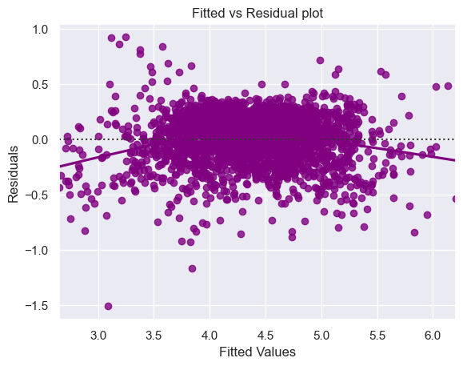

```python
sns.residplot(
    data=df_pred, x="Fitted Values", y="Residuals", color="purple", lowess=True
)
plt.xlabel("Fitted Values")
plt.ylabel("Residuals")
plt.title("Fitted vs Residual plot")
plt.show()
```

### TEST FOR NORMALITY

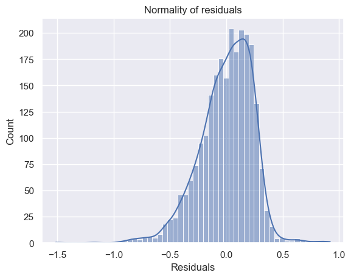

```python
sns.histplot(data=df_pred, x="Residuals", kde=True)
plt.title("Normality of residuals")
plt.show()
```

The histogram plot is a bel-shaped curve. But a Q-Q plot will be drawn for further analysis.

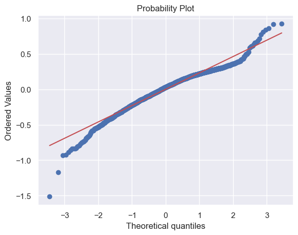

```python
import pylab
import scipy.stats as stats

stats.probplot(df_pred["Residuals"], dist="norm", plot=pylab)
plt.show()
```

Other than the tails on both ends, the residuals more or less follow a straight line. For further analysis, a Shapiro-Wilks test will be carried out.

```python
stats.shapiro(df_pred["Residuals"])
```

```
ShapiroResult(statistic=0.9676950829900569, pvalue=6.983856712612207e-23)
```

Since the p-value < 0.05, the residuals are not normal as per the Shapiro-Wilk test. The residuals are not normal strictly speaking. But, as an approximation, this distribution is close to being normal.

Therefore, the assumption for normality is satisfied.

### TEST FOR HOMOSCEDASTICITY

```python
import statsmodels.stats.api as sms
from statsmodels.compat import lzip

name = ["F statistic", "p-value"]
test = sms.het_goldfeldquandt(df_pred["Residuals"], X_train3)
lzip(name, test)
```

```
[('F statistic', 1.008750419910676), ('p-value', 0.4401970650667301)]
```

Since p-value > 0.05, it's safe to say that the residuals are homoscedastic. Thus, this assumption is satisfied.

### Predictions on Test Data Set

```python
pred = model2.predict(X_test3)

df_pred_test = pd.DataFrame({"Actual": y_test, "Predicted": pred})
df_pred_test.sample(10, random_state=1)
```

|  | Actual | Predicted |
| --- | --- | --- |
| 1995 | 4.566741 | 4.385671 |
| 2341 | 3.696103 | 4.003934 |
| 1913 | 3.592093 | 3.643812 |
| 688 | 4.306495 | 4.103463 |
| 650 | 4.522115 | 5.113026 |
| 2291 | 4.259294 | 4.398406 |
| 40 | 4.997685 | 5.459871 |
| 1884 | 3.875359 | 4.053143 |
| 2538 | 4.206631 | 4.035868 |
| 45 | 5.380450 | 5.227899 |

The actual and predicted results are comparable. It is therefore safe to say that the model has done a pretty good job.

## Final Model

```python
X_train_final = X_train3.copy()
X_test_final = X_test3.copy()
```

```python
model_final = sm.OLS(y_train, X_train_final).fit()
print(model_final.summary())
```

```
                              OLS Regression Results
=================================================================================
Dep. Variable:     normalized_used_price   R-squared:                       0.839
Model:                               OLS   Adj. R-squared:                  0.838
Method:                    Least Squares   F-statistic:                     895.7
Date:                   Sat, 12 Apr 2025   Prob (F-statistic):               0.00
Time:                           15:59:36   Log-Likelihood:                 80.645
No. Observations:                   2417   AIC:                            -131.3
Df Residuals:                       2402   BIC:                            -44.44
Df Model:                             14
Covariance Type:               nonrobust
========================================================================================
                           coef    std err          t      P>|t|      [0.025      0.975]
----------------------------------------------------------------------------------------
const                    1.5000      0.048     30.955      0.000       1.405       1.595
main_camera_mp           0.0210      0.001     14.714      0.000       0.018       0.024
selfie_camera_mp         0.0138      0.001     12.858      0.000       0.012       0.016
ram                      0.0207      0.005      4.151      0.000       0.011       0.030
weight                   0.0017      6e-05     27.672      0.000       0.002       0.002
normalized_new_price     0.4415      0.011     39.337      0.000       0.419       0.463
years_since_release     -0.0292      0.003     -8.589      0.000      -0.036      -0.023
brand_name_Karbonn       0.1156      0.055      2.111      0.035       0.008       0.223
brand_name_Samsung      -0.0374      0.016     -2.270      0.023      -0.070      -0.005
brand_name_Sony         -0.0670      0.030     -2.197      0.028      -0.127      -0.007
brand_name_Xiaomi        0.0801      0.026      3.114      0.002       0.030       0.130
os_Others               -0.1276      0.027     -4.667      0.000      -0.181      -0.074
os_iOS                  -0.0900      0.045     -1.994      0.046      -0.179      -0.002
4g_yes                   0.0502      0.015      3.326      0.001       0.021       0.080
5g_yes                  -0.0673      0.031     -2.194      0.028      -0.127      -0.007
==============================================================================
Omnibus:                      246.183   Durbin-Watson:                   1.902
Prob(Omnibus):                  0.000   Jarque-Bera (JB):              483.879
Skew:                          -0.658   Prob(JB):                    8.45e-106
Kurtosis:                       4.753   Cond. No.                     2.39e+03
==============================================================================

Notes:
[1] Standard Errors assume that the covariance matrix of the errors is correctly specified.
[2] The condition number is large, 2.39e+03. This might indicate that there are
strong multicollinearity or other numerical problems.
```

```python
# Checking model performance on train set
print("Training Performance\n")
model_final_train_perfomance = model_performance_regression(
    model_final, X_train_final, y_train
)
model_final_train_perfomance
```

```
Training Performance
```

|  | RMSE | MAE | R-squared | Adj. R-squared | MAPE |
| --- | --- | --- | --- | --- | --- |
| 0 | 0.23403 | 0.182751 | 0.83924 | 0.838235 | 4.395407 |

```python
# Checking model performance on test set
print("Test Performance\n")
model_final_test_perfomance = model_performance_regression(
    model_final, X_test_final, y_test
)
model_final_test_perfomance
```

```
Test Performance
```

|  | RMSE | MAE | R-squared | Adj. R-squared | MAPE |
| --- | --- | --- | --- | --- | --- |
| 0 | 0.241434 | 0.186649 | 0.838387 | 0.836013 | 4.556349 |

## Actionable Insights and Recommendations

#### 1. **Pricing Model Design**

- Use the `years since release` as a key factor in your price prediction models — older devices usually trend lower.
- Segment pricing strategies by `brand_name`. Treat high-end brands like Apple and Samsung differently from more budget-friendly ones like Xiaomi or Realme.

#### 5. **Customer Targeting**

- Offer older but capable models to price-sensitive buyers, who are looking for value without breaking the bank.
- For heavier phones, consider bundling with comfort accessories like grip cases or stands to enhance the user experience.